# Principal Component Analysis

Dataset happy

This dataset contains 157 individuals and 10 variables, 1 quantitative variable is considered as illustrative, 1 qualitative variable is considered as illustrative.

### 1. Study of the outliers

The analysis of the graphs does not detect any outlier.

### 2. Inertia distribution

The inertia of the first dimensions shows if there are strong relationships between variables and suggests the number of dimensions that should be studied.

The first two dimensions of PCA express **65.58%** of the total dataset inertia ; that means that 65.58% of the individuals (or variables) cloud total variability is explained by the plane. This percentage is relatively high and thus the first plane well represents the data variability. This value is strongly greater than the reference value that equals **33.97%**, the variability explained by this plane is thus highly significant (the reference value is the 0.95-quantile of the inertia percentages distribution obtained by simulating 774 data tables of equivalent size on the basis of a normal distribution).

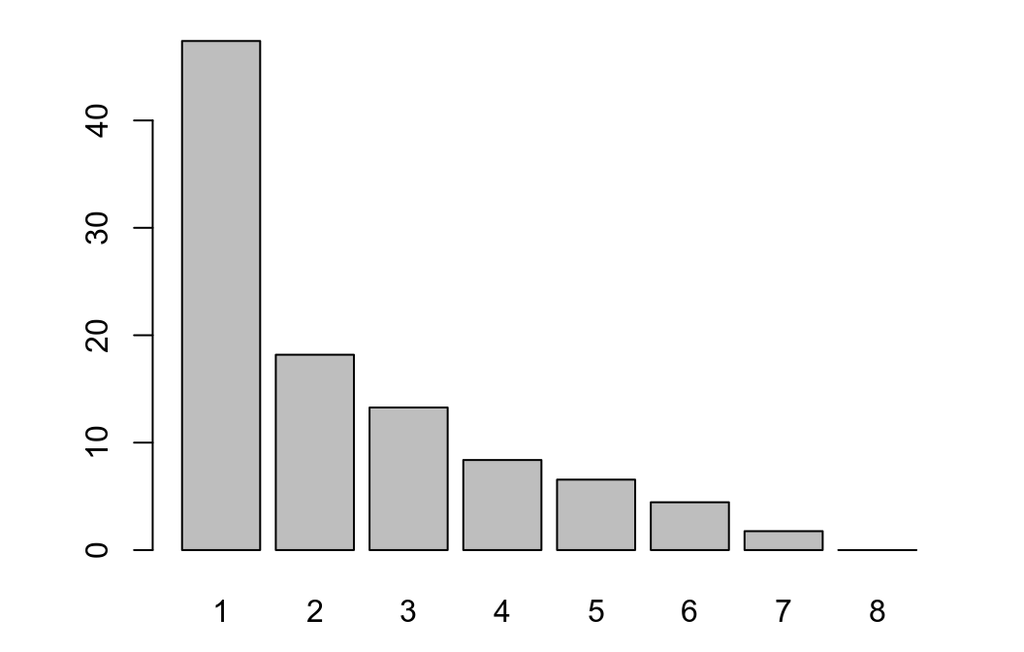

**Figure 2 - Decomposition of the total inertia on the components of the PCA**

An estimation of the right number of axis to interpret suggests to restrict the analysis to the description of the first 2 axis. These axis present an amount of inertia greater than those obtained by the 0.95-quantile of random distributions (65.58% against 33.97%). This observation suggests that only these axis are carrying a real information. As a consequence, the description will stand to these axis.

### 3. Description of the plane 1:2

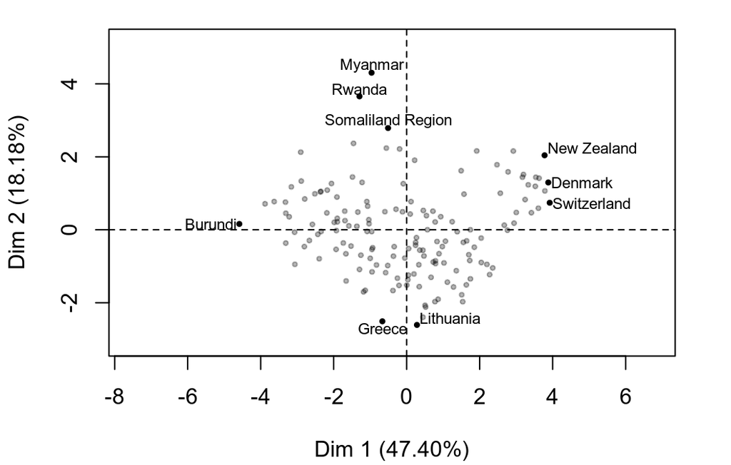

**Figure 3.1 - Individuals factor map (PCA)** *The labeled individuals are those with the higher contribution to the plane construction.*

The Wilks test p-value indicates which variable factors are the best separated on the plane (i.e. which one explain the best the distance between individuals).

```
##       Region
## 1.217174e-38
```

There only is one possible qualitative variable to illustrate the distance between individuals : *Region*.

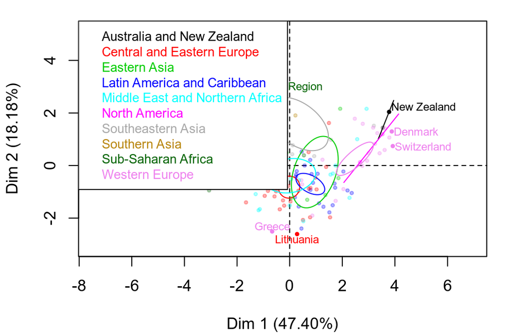

**Figure 3.2 - Individuals factor map (PCA)** *The labeled individuals are those with the higher contribution to the plane construction.* *The individuals are coloured after their category for the variable* Region.

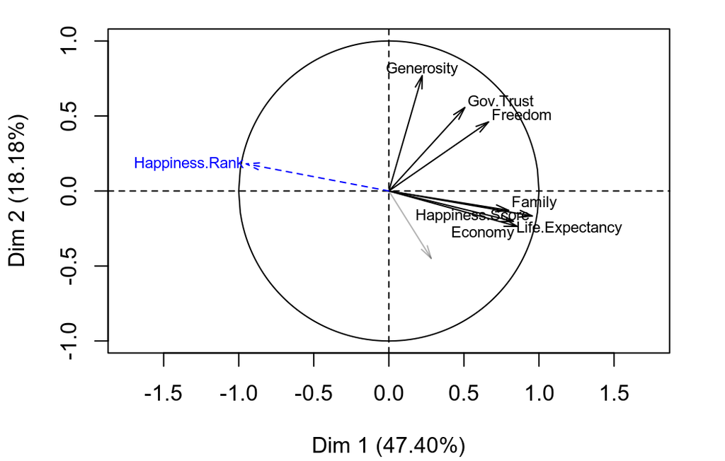

**Figure 3.3 - Variables factor map (PCA)** *The variables in black are considered as active whereas those in blue are illustrative.* *The labeled variables are those the best shown on the plane.*

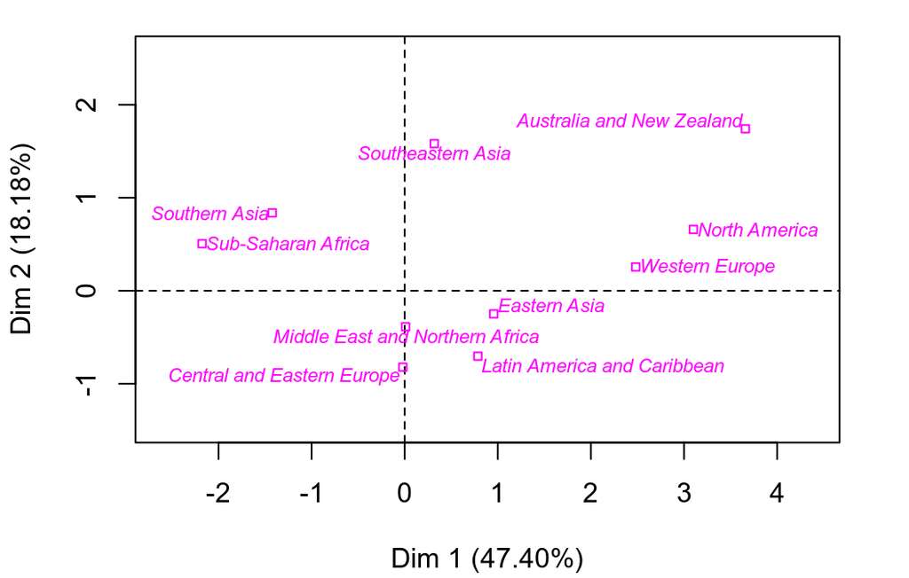

**Figure 3.4 - Qualitative factor map (PCA)** *The labeled factors are those the best shown on the plane.*

The group in which the individuals *Lithuania* and *Greece* stand (characterized by a positive coordinate on the axis) is sharing :

- high values for the variables *Dystopia.Resid*, *Life.Expectancy*, *Economy*, *Happiness.Score* and *Family* (variables are sorted from the strongest).
- low values for the variables *Generosity*, *Happiness.Rank* and *Gov.Trust* (variables are sorted from the weakest).

The group in which the individuals *New Zealand*, *Switzerland* and *Denmark* stand (characterized by a positive coordinate on the axis) is sharing :

- high values for the variables *Gov.Trust*, *Happiness.Score*, *Freedom*, *Economy*, *Life.Expectancy*, *Family* and *Generosity* (variables are sorted from the strongest).
- low values for the variable *Happiness.Rank*.

The group in which the individuals *Burundi*, *Myanmar*, *Somaliland Region* and *Rwanda* stand (characterized by a negative coordinate on the axis) is sharing :

- high values for the variable *Happiness.Rank*.
- low values for the variables *Happiness.Score*, *Economy*, *Life.Expectancy*, *Family*, *Dystopia.Resid*, *Freedom* and *Gov.Trust* (variables are sorted from the weakest).

The **dimension 2** opposes individuals such as *New Zealand*, *Burundi*, *Switzerland*, *Denmark*, *Myanmar*, *Somaliland Region* and *Rwanda* (to the top of the graph, characterized by a strongly positive coordinate on the axis) to individuals such as *Lithuania* and *Greece* (to the bottom of the graph, characterized by a strongly negative coordinate on the axis).

The group in which the individuals *Burundi*, *Myanmar*, *Somaliland Region* and *Rwanda* stand (characterized by a positive coordinate on the axis) is sharing :

- high values for the variable *Happiness.Rank*.
- low values for the variables *Happiness.Score*, *Economy*, *Life.Expectancy*, *Family*, *Dystopia.Resid*, *Freedom* and *Gov.Trust* (variables are sorted from the weakest).

The group in which the individuals *New Zealand*, *Switzerland* and *Denmark* stand (characterized by a positive coordinate on the axis) is sharing :

- high values for the variables *Gov.Trust*, *Happiness.Score*, *Freedom*, *Economy*, *Life.Expectancy*, *Family* and *Generosity* (variables are sorted from the strongest).
- low values for the variable *Happiness.Rank*.

The group in which the individuals *Lithuania* and *Greece* stand (characterized by a negative coordinate on the axis) is sharing :

- high values for the variables *Dystopia.Resid*, *Life.Expectancy*, *Economy*, *Happiness.Score* and *Family* (variables are sorted from the strongest).
- low values for the variables *Generosity*, *Happiness.Rank* and *Gov.Trust* (variables are sorted from the weakest).

### 4. Classification

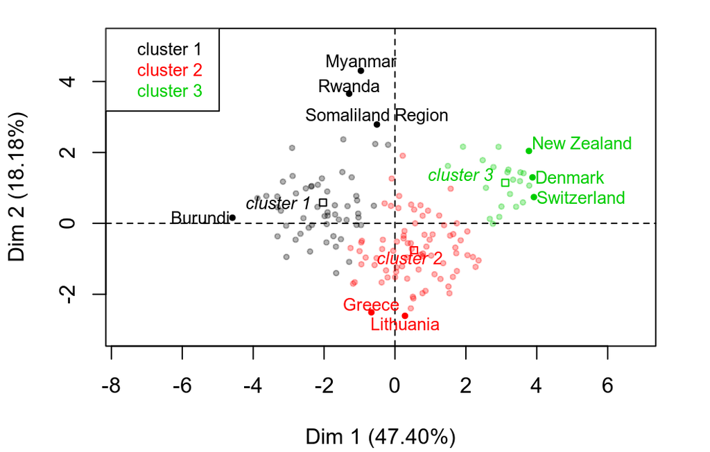

**Figure 4 - Ascending Hierarchical Classification of the individuals.** *The classification made on individuals reveals 3 clusters.*

The **cluster 1** is made of individuals such as *Somaliland Region*, *Myanmar*, *Rwanda* and *Burundi*. This group is characterized by :

- high values for the variable *Happiness.Rank*.
- low values for the variables *Life.Expectancy*, *Happiness.Score*, *Economy*, *Family*, *Freedom* and *Dystopia.Resid* (variables are sorted from the weakest).

The **cluster 2** is made of individuals such as *Lithuania* and *Greece*. This group is characterized by :

- high values for the variables *Life.Expectancy*, *Economy*, *Family*, *Happiness.Score* and *Dystopia.Resid* (variables are sorted from the strongest).
- low values for the variables *Gov.Trust*, *Happiness.Rank* and *Generosity* (variables are sorted from the weakest).

The **cluster 3** is made of individuals such as *Denmark*, *Switzerland* and *New Zealand*. This group is characterized by :

- high values for the variables *Gov.Trust*, *Happiness.Score*, *Freedom*, *Economy*, *Life.Expectancy*, *Generosity* and *Family* (variables are sorted from the strongest).
- low values for the variable *Happiness.Rank*.

## Annexes

```r
dimdesc(res, axes = 1:2)
```

```
$Dim.1
$Dim.1$quanti
                correlation      p.value
Happiness.Score   0.9553802 5.425542e-84
Economy           0.8546076 5.751968e-46
Life.Expectancy   0.8288425 6.211647e-41
Family            0.7975802 7.510795e-36
Freedom           0.6638259 2.661724e-21
Gov.Trust         0.5061513 1.356569e-11
Dystopia.Resid    0.2818863 3.480804e-04
Generosity        0.2220728 5.184842e-03
Happiness.Rank   -0.9499148 3.402396e-80

$Dim.1$quali
              R2      p.value
Region 0.6562219 6.294135e-30

$Dim.1$category
                               Estimate      p.value
Western Europe               1.71247201 2.416330e-11
Australia and New Zealand    2.89020422 7.271575e-03
North America                2.33137923 2.341061e-02
Latin America and Caribbean  0.01690555 3.182621e-02
Southern Asia               -2.19218470 4.826047e-02
Sub-Saharan Africa          -2.94507858 7.480033e-19


$Dim.2
$Dim.2$quanti
                correlation      p.value
Generosity        0.7684743 7.309464e-32
Gov.Trust         0.5565514 3.781183e-14
Freedom           0.4602257 1.325402e-09
Happiness.Rank    0.1808576 2.340509e-02
Happiness.Score  -0.1665005 3.714699e-02
Life.Expectancy  -0.2021126 1.113352e-02
Economy          -0.2359043 2.936116e-03
Dystopia.Resid   -0.4491128 3.640468e-09

$Dim.2$quali
             R2      p.value
Region 0.350763 1.478002e-10

$Dim.2$category
                              Estimate      p.value
Southeastern Asia            1.2391437 3.625338e-05
Sub-Saharan Africa           0.1644291 2.761313e-03
Australia and New Zealand    1.3982693 4.023569e-02
Latin America and Caribbean -1.0450179 1.773840e-03
Central and Eastern Europe  -1.1635167 3.452900e-05
```

**Figure 5 - List of variables characterizing the dimensions of the analysis.**

```r
res.hcpc$desc.var
```

```
Link between the cluster variable and the categorical variables (chi-square test)
=================================================================================
            p.value df
Region 4.444738e-29 18

Description of each cluster by the categories
=============================================
$`1`
                                     Cla/Mod   Mod/Cla    Global
Region=Sub-Saharan Africa          97.368421 66.071429 24.203822
Region=Southern Asia               85.714286 10.714286  4.458599
Region=Central and Eastern Europe  10.344828  5.357143 18.471338
Region=Latin America and Caribbean  4.166667  1.785714 15.286624
Region=Western Europe               0.000000  0.000000 13.375796
                                        p.value    v.test
Region=Sub-Saharan Africa          1.076684e-20  9.328215
Region=Southern Asia               9.189222e-03  2.604933
Region=Central and Eastern Europe  1.016931e-03 -3.285800
Region=Latin America and Caribbean 1.583119e-04 -3.777655
Region=Western Europe              4.108495e-05 -4.101292

$`2`
                                     Cla/Mod   Mod/Cla   Global
Region=Latin America and Caribbean 95.833333 29.487179 15.28662
Region=Central and Eastern Europe  86.206897 32.051282 18.47134
Region=Sub-Saharan Africa           2.631579  1.282051 24.20382
                                        p.value    v.test
Region=Latin America and Caribbean 2.268657e-07  5.175858
Region=Central and Eastern Europe  9.185167e-06  4.435517
Region=Sub-Saharan Africa          9.223697e-13 -7.141620

$`3`
                                     Cla/Mod   Mod/Cla    Global
Region=Western Europe               66.66667 60.869565 13.375796
Region=North America               100.00000  8.695652  1.273885
Region=Australia and New Zealand   100.00000  8.695652  1.273885
Region=Latin America and Caribbean   0.00000  0.000000 15.286624
Region=Sub-Saharan Africa            0.00000  0.000000 24.203822
                                        p.value    v.test
Region=Western Europe              1.824326e-09  6.012723
```

[output cut: 63 more lines]

```
Freedom          6.424332         1.237561  6.462674e-17      0.2450002
Economy          6.353622         1.223940 -7.409037e-17      0.4596573
Life.Expectancy  5.708758         1.099715 -2.264422e-16      0.3649768
Generosity       5.370017         1.034461  1.381149e-18      0.6673966
Family           5.345381         1.029716  1.509375e-16      0.3729070
Happiness.Rank  -6.952618        18.086957  7.898089e+01     16.8546550
                Overall sd      p.value
Gov.Trust        0.9968102 2.850071e-18
Happiness.Score  0.9968102 4.590449e-13
Freedom          0.9968102 1.324499e-10
Economy          0.9968102 2.103028e-10
Life.Expectancy  0.9968102 1.138033e-08
Generosity       0.9968102 7.872943e-08
Family           0.9968102 9.022700e-08
Happiness.Rank  45.3210025 3.585694e-12
```

**Figure 6 - List of variables characterizing the clusters of the classification.**